# Formula 1

```r
TwitterDatabyHashtag<- TwitterData %>%
  group_by(hashtags) %>%
  summarise(
    n = n()
  )
TwitterDatabyHashtag
```

| hashtags | n |
| --- | --- |
| __ ElectionNight Congress DemocraticParty | 4 |
| __ ElectionNight Congress DemocraticParty Republicans FloridaElection _ | 1 |
| _ ElectionNight Congress DemocraticParty | 5 |
| _ ElectionNight Congress DemocraticParty Republicans FloridaElection _ | 1 |
| _ _ ElectionNight Congress DemocraticParty Republicans | 4 |
| _ _ ElectionNight Congress DemocraticParty Republicans FloridaElection _ | 1 |
| _ ElectionNight Congress DemocraticParty | 7 |
| _ ElectionNight Congress DemocraticParty Republicans FloridaElection _ | 1 |
| ElectionNight Congress DemocraticParty | 3 |
| ElectionNight Congress DemocraticParty Republicans FloridaElection _ | 1 |

[output cut: 990 more lines]

#View Data By Hashtag

```r
TwitterDatabyHashtag
```

| hashtags | n |
| --- | --- |
| __ ElectionNight Congress DemocraticParty | 4 |
| __ ElectionNight Congress DemocraticParty Republicans FloridaElection _ | 1 |
| _ ElectionNight Congress DemocraticParty | 5 |
| _ ElectionNight Congress DemocraticParty Republicans FloridaElection _ | 1 |
| _ _ ElectionNight Congress DemocraticParty Republicans | 4 |
| _ _ ElectionNight Congress DemocraticParty Republicans FloridaElection _ | 1 |
| _ ElectionNight Congress DemocraticParty | 7 |
| _ ElectionNight Congress DemocraticParty Republicans FloridaElection _ | 1 |
| ElectionNight Congress DemocraticParty | 3 |
| ElectionNight Congress DemocraticParty Republicans FloridaElection _ | 1 |

[output cut: 990 more lines]

#Republican ReTweets

```r
RepublicanTweets <-  TwitterDatabyHashtag %>% filter(str_detect(hashtags, "maga|republican|trump|desantis| De Santis| GOP | gop | FOX|potus"))
RepublicanTweets
```

| hashtags | n |
| --- | --- |
| 2a nra maga potus trump fbr vp gop resist fires impeach nfl mueller FloridaRecount2018 | 1 |
| 2a nra maga potus trump fbr vp gop resist fl gillum | 1 |
| 2a nra maga potus trump fbr vp gop resist impeach nfl fl Gillum whitaker sessions ag mueller | 1 |
| 2a nra maga potus trump fbr vp gop resist impeach nfl LIndsey fl whitaker mueller gillum scott | 1 |
| acosta today women TheResistance TrumpRussia GOPCorruption GOPComplicit Democrats stoptrump WomensMarch Resisters Resistance Florida FloridaRecount democracy Mueller MuellerProbe DemsTakeTheHouse | 1 |
| America BrowardCounty VoterFraud BrendaSnipes StopTheSteal VoterFraud StopTheStealFL FloridaRecount2018 FloridaRecount DebbieWassermanSchultz BorderLineShooting FalseFlag DrainTheDeepState maga | 1 |
| AndrewGillum CountEveryVote GOP ElectionFraud VeteransDay2018 Florida | 1 |
| andrewgillum obama gillumforgovernor gillum presidentobama floridagovernor vote votetomorrow votedemocrat voterepublican sorrynotsorry itsajoke justkidding pts kod | 1 |
| andrewgillum USA Midterms2018 MidtermsElections2018 Rondesantis FloridaRecount2018 Florida FloridaVoterFraud | 1 |
| AngryInFlorida GOP FloridaRecount | 1 |

[output cut: 791 more lines]

#Most Popular Republican Hashtag reTweets

```r
arrange(RepublicanTweets, desc(n))
```

| hashtags | n |
| --- | --- |
| Gillum EthicsScandal GOP Racist VoteRedToSaveAmerica2018 | 367 |
| maga BrendaSnipes qanon FloridaRecount2018 | 145 |
| magaPatriots FloridaRecount | 31 |
| maga | 25 |
| republican lawyers STOPTHEVOTERFRAUD | 18 |
| UnfitForOffice TRUMPRUSSIA protectMueller protectthecountry trumprussia azsen flsen | 14 |
| StopTheSteal FloridaRecount blacksfortrump | 11 |
| trump | 10 |
| Trump GOP UnderminingUSElections VoteSuppression FloridaRecount CountEveryVote Florida | 9 |
| gillum desantis | 8 |

[output cut: 791 more lines]

```r
mostpopularrep <- filter(RepublicanTweets, hashtags == "maga BrendaSnipes qanon FloridaRecount2018" |
         hashtags == "magaPatriots FloridaRecount"|
         hashtags == "maga")
mostpopularrep
```

| hashtags | n |
| --- | --- |
| maga | 25 |
| maga BrendaSnipes qanon FloridaRecount2018 | 145 |
| magaPatriots FloridaRecount | 31 |

#Top Republican reTweets hashtag excluding negative keywords

```r
RepublicanTweets %>% filter(!str_detect(hashtags, "corrupt | liar | impeach | fuck | stop | tyrant | dictator|fucktrump | nazi"))
```

| hashtags | n |
| --- | --- |
| 2a nra maga potus trump fbr vp gop resist fl gillum | 1 |
| acosta today women TheResistance TrumpRussia GOPCorruption GOPComplicit Democrats stoptrump WomensMarch Resisters Resistance Florida FloridaRecount democracy Mueller MuellerProbe DemsTakeTheHouse | 1 |
| America BrowardCounty VoterFraud BrendaSnipes StopTheSteal VoterFraud StopTheStealFL FloridaRecount2018 FloridaRecount DebbieWassermanSchultz BorderLineShooting FalseFlag DrainTheDeepState maga | 1 |
| AndrewGillum CountEveryVote GOP ElectionFraud VeteransDay2018 Florida | 1 |
| andrewgillum obama gillumforgovernor gillum presidentobama floridagovernor vote votetomorrow votedemocrat voterepublican sorrynotsorry itsajoke justkidding pts kod | 1 |
| andrewgillum USA Midterms2018 MidtermsElections2018 Rondesantis FloridaRecount2018 Florida FloridaVoterFraud | 1 |
| AngryInFlorida GOP FloridaRecount | 1 |
| AngryMob Trump GOP VoterSuppressors CountAllTheVotes Florida FloridaRecount AndrewGillum | 5 |
| arizona arizonaelection mcsally sinema recount resist notmypresident trump mueller resistance imwithher impeachtrump trumprussia muellertime midterms2018 bluewave bluewave2018 metoo trumpresign florid… | 1 |
| Arizona ballots Senate Desperate republican ploy CountEveryVote SenatorSinema | 1 |

[output cut: 770 more lines]

```
Ignoring unknown parameters: stat
```

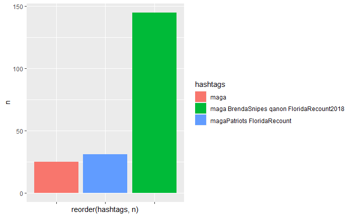

```r
ggplot (data = mostpopularrep) + geom_col(mapping = aes (x= reorder(hashtags, n), y = n, fill = hashtags), stat = "count") +
  theme(axis.text.x = element_blank())
```

```
Ignoring unknown parameters: stat
```

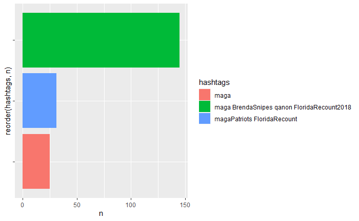

```r
ggplot (data = mostpopularrep) + geom_col(mapping = aes (x= reorder(hashtags, n), y = n, fill = hashtags), stat = "count") +
  coord_flip() +
  theme(axis.text.y = element_blank())
```

#Democrat Tweets #Count every time there’s a democrat hashtag retweet vs a Republican hashtag reTweet

```r
democrattweets <- TwitterDatabyHashtag %>% filter(str_detect(hashtags, "democrat | liberal| dem|BlueWave| hilary | CNN | obama | OBAMA "))

tw_data <- TwitterData %>%
  mutate(
    Dem_favor_flag = 0,
    Rep_favor_flag = 0
  )
tw_data <- tw_data %>%
  mutate(
    Dem_favor_flag = replace(Dem_favor_flag, str_detect(hashtags, "democrat | liberal| dem|BlueWave| hilary | CNN | obama | OBAMA "), 1)
  )
tw_data <- tw_data %>%
  mutate(
    Rep_favor_flag = replace(Rep_favor_flag, str_detect(hashtags, "maga|republican|trump|desantis| De Santis| GOP | gop | FOX|potus"), 1)
  )
tw_data
```

| hashtags | tweettype | retweet_count | user_friends_count | Dem_favor_flag | Rep_favor_flag |
| --- | --- | --- | --- | --- | --- |
| FloridaElection | retweet | 7528 | 748 | 0 | 0 |
| FloridaRecount | retweet | 483 | 3624 | 0 | 0 |
| FloridaRecount | original | 0 | 952 | 0 | 0 |
| FloridaRecount | retweet | 27 | 2808 | 0 | 0 |
| FloridaRecount | quote | 9 | 434 | 0 | 0 |
| NA | retweet | 180 | 228 | 0 | 0 |
| FloridaElection | retweet | 7528 | 262 | 0 | 0 |
| FloridaRecount | reply | 11 | 1629 | 0 | 0 |
| FloridaElection | retweet | 7528 | 2245 | 0 | 0 |
| NA | retweet | 320 | 2805 | 0 | 0 |

[output cut: 990 more lines]

#Find the average counts per hashtag retweet:

```r
tw_data2 <- select(tw_data, Dem_favor_flag, Rep_favor_flag) %>%
      summarise(
        avgDemCounts = mean(Dem_favor_flag),
        avgRepCounts = mean(Rep_favor_flag))
   tw_data2
```

| avgDemCounts | avgRepCounts |
| --- | --- |
| 0.002514801 | 0.001820565 |

#On average, democrat hashtags appear more than republican hashtags. This means that more hashtags include the keywords “democrat | liberal| dem|BlueWave| hilary | CNN | obama | OBAMA”, than the keywords “maga|republican|trump|desantis| De Santis| GOP | gop | FOX|potus”.

#Find total count of Democrat vs Republican Hashtag retweet:

```r
tw_data3 <- select(tw_data, Dem_favor_flag, Rep_favor_flag) %>%
      summarise(
        sumDemCounts = sum(Dem_favor_flag),
        sumRepCounts = sum(Rep_favor_flag))
   tw_data3
```

| sumDemCounts | sumRepCounts |
| --- | --- |
| 2264 | 1639 |

#From this summary we can tell that there are more instances of Democrat hashtag retweets than there are of Republican Hashtags.

#Find democrat hashtags that excluse negative terms

```r
democrattweetsexcluding <-  democrattweets %>% filter(!str_detect(hashtags, " fake | corrupt |socialists| CrookedHillary | emails"))
democrattweetsexcluding
```

| hashtags | n |
| --- | --- |
| 2018Midterms FloridaElection FloridaElectionFraud BrowardElection democrats MAGA2020 vote | 1 |
| 2018Midterms FloridaVoters Gillum BlueWaveComing BREAKING BringItHome | 1 |
| 30DaysSober ElectionDay Midterms2018 BlueWave bringithome gillum nelson | 1 |
| ABC CBS NBC MSNBC CNN BBC NPR NYT WSJ USAToday GMA LATimes ChicagoTribune TuesdayMotivation Detroit NYC | 1 |
| ABC CBS NBC MSNBC CNN BBC NPR NYT WSJ USAToday GMA LATimes ChicagoTribune TuesdayMotivation Detroit NYC LA Miami Tampa Florida Chicago BLEXIT Dallas Houston Boston FortWorth Denver FloridaRecount FlSe… | 5 |
| Acosta CNN CaravanInvasion Pelosi FloridaRecount vaccination Dental EPA toxicity NewZealand Testimatic | 1 |
| acosta today women TheResistance TrumpRussia GOPCorruption GOPComplicit Democrats stoptrump WomensMarch Resisters Resistance Florida FloridaRecount democracy Mueller MuellerProbe DemsTakeTheHouse | 1 |
| AlternativeFacts FakeNews FloridaRecount democratic government BeBest | 1 |
| Amen BlueWave CountEveryVote WeThePeople Democracy | 1 |
| AmericaFirst Blexit BlueWave Democrats FloridaElection | 1 |

[output cut: 990 more lines]

#when we exclude negative terms such as " fake | corrupt |socialists| CrookedHillary | emails" from the hashtags, there’s 4 less reteewts of hashtags. This means that 1,006 democrat hashtag retweets are positive and approximately 4 democrat hashtag retweets are negative

#Looking at Hashtag retweet per User friends and followers:

#Filter per user followers, user friends, hashtags, tweet type and retweet count

```r
TwitterUsers <- c("user_followers_count", "user_friends_count", "hashtags", "tweettype", "retweet_count")
usersData <- TwitterPoliticalData[, TwitterUsers]
usersData
```

| user_followers_count | user_friends_count | hashtags | tweettype | retweet_count |
| --- | --- | --- | --- | --- |
| 452 | 748 | FloridaElection | retweet | 7528 |
| 2885 | 3624 | FloridaRecount | retweet | 483 |
| 723 | 952 | FloridaRecount | original | 0 |
| 3866 | 2808 | FloridaRecount | retweet | 27 |
| 266 | 434 | FloridaRecount | quote | 9 |
| 340 | 228 | NA | retweet | 180 |
| 355 | 262 | FloridaElection | retweet | 7528 |
| 29807 | 1629 | FloridaRecount | reply | 11 |
| 619 | 2245 | FloridaElection | retweet | 7528 |
| 2833 | 2805 | NA | retweet | 320 |

[output cut: 990 more lines]

#Filter per specific hashtags

```r
tweetuserdata <- usersData %>% filter(str_detect(hashtags, "democrat | liberal | obama | trump | cnn")) %>%
  summary(tweetuserdata)
tweetuserdata
```

```
 user_followers_count user_friends_count   hashtags          tweettype         retweet_count
 Min.   :     4       Min.   :    0      Length:265         Length:265         Min.   : 0.000
 1st Qu.:   305       1st Qu.:  258      Class :character   Class :character   1st Qu.: 0.000
 Median :   647       Median : 1055      Mode  :character   Mode  :character   Median : 1.000
 Mean   :  6496       Mean   : 2608                                            Mean   : 4.094
 3rd Qu.:  3184       3rd Qu.: 2790                                            3rd Qu.: 4.000
 Max.   :407399       Max.   :31918                                            Max.   :87.000
```

```r
usersData
```

| user_followers_count | user_friends_count | hashtags | tweettype | retweet_count |
| --- | --- | --- | --- | --- |
| 452 | 748 | FloridaElection | retweet | 7528 |
| 2885 | 3624 | FloridaRecount | retweet | 483 |
| 723 | 952 | FloridaRecount | original | 0 |
| 3866 | 2808 | FloridaRecount | retweet | 27 |
| 266 | 434 | FloridaRecount | quote | 9 |
| 340 | 228 | NA | retweet | 180 |
| 355 | 262 | FloridaElection | retweet | 7528 |
| 29807 | 1629 | FloridaRecount | reply | 11 |
| 619 | 2245 | FloridaElection | retweet | 7528 |
| 2833 | 2805 | NA | retweet | 320 |

[output cut: 990 more lines]

#Summarise user_followers_cunt and retweet_count per hashtag

```r
TweetFollowersbyHashtag <- usersData %>%
  group_by(hashtags) %>%
summarise (
  SumFollowerCount = sum(user_followers_count),
  SumRetweets = sum(retweet_count)
)
TweetFollowersbyHashtag
```

| hashtags | SumFollowerCount | SumRetweets |
| --- | --- | --- |
| __ ElectionNight Congress DemocraticParty | 79848 | 24 |
| __ ElectionNight Congress DemocraticParty Republicans FloridaElection _ | 67058 | 6 |
| _ ElectionNight Congress DemocraticParty | 89563 | 40 |
| _ ElectionNight Congress DemocraticParty Republicans FloridaElection _ | 67058 | 8 |
| _ _ ElectionNight Congress DemocraticParty Republicans | 52930 | 28 |
| _ _ ElectionNight Congress DemocraticParty Republicans FloridaElection _ | 67058 | 7 |
| _ ElectionNight Congress DemocraticParty | 140186 | 63 |
| _ ElectionNight Congress DemocraticParty Republicans FloridaElection _ | 67058 | 9 |
| ElectionNight Congress DemocraticParty | 81657 | 15 |
| ElectionNight Congress DemocraticParty Republicans FloridaElection _ | 67058 | 5 |

[output cut: 990 more lines]

#Explain your exploratory analysis, hypothesis analyses, and independent/dependent variable declaration

#Normality test >#Testing for normality:

#Variables >#Our independent variable: ># Retweets of a hashtag

> #Our dependent variables:

> #Republican Hashtag Retweets #Democrat Hashtag Retweets

#Hypothesis Testing

#Hypothesis

> #our Hypothesis: Hashtag Retweets for Democrats are equal to Republicans

```r
retweetonasum<- group_by(TwitterData, hashtags)
retweetssum <- summarise(retweetonaverage,
                         sumtweets=sum(retweet_count))
retweetssum
```

| hashtags | sumtweets |
| --- | --- |
| __ ElectionNight Congress DemocraticParty | 24 |
| __ ElectionNight Congress DemocraticParty Republicans FloridaElection _ | 6 |
| _ ElectionNight Congress DemocraticParty | 40 |
| _ ElectionNight Congress DemocraticParty Republicans FloridaElection _ | 8 |
| _ _ ElectionNight Congress DemocraticParty Republicans | 28 |
| _ _ ElectionNight Congress DemocraticParty Republicans FloridaElection _ | 7 |
| _ ElectionNight Congress DemocraticParty | 63 |
| _ ElectionNight Congress DemocraticParty Republicans FloridaElection _ | 9 |
| ElectionNight Congress DemocraticParty | 15 |
| ElectionNight Congress DemocraticParty Republicans FloridaElection _ | 5 |

[output cut: 990 more lines]

#Are the retweet counts for the Democrat Party hashtags significantly different than the retweet counts for the Republican Party hashtags?

```r
#Filter group 1 and 2
Group1 <- filter(TwitterPoliticalData,str_detect(hashtags, "maga|republican|trump|desantis| De Santis| GOP | gop | FOX|potus"))
Group2 <- filter(TwitterPoliticalData,str_detect(hashtags, "democrat | liberal| dem|BlueWave| hilary | CNN | obama | OBAMA "))
```

#Test for Normality

```r
shapiro.test(Group1$retweet_count)
```

```
    Shapiro-Wilk normality test

data:  Group1$retweet_count
W = 0.58033, p-value < 2.2e-16
```

```r
shapiro.test(Group2$retweet_count)
```

```
    Shapiro-Wilk normality test

data:  Group2$retweet_count
W = 0.56008, p-value < 2.2e-16
```

#Not normal distribution

#Wilcox Test

```r
wilcox.test(Group1$retweet_count, Group2$retweet_count, PAIRED = FALSE)
```

```
    Wilcoxon rank sum test with continuity correction

data:  Group1$retweet_count and Group2$retweet_count
W = 1938518, p-value = 0.01453
alternative hypothesis: true location shift is not equal to 0
```

#P value is smaller than alpha, we reject the null hypothesis. We support the claim that there is a significant difference between the retweet counts for the Democrat Hashtags and the Republican Hashtags.

#Mean and standard deviation

```r
retweetonaverage<- group_by(TwitterData, hashtags)
retweetssummary <- summarise(retweetonaverage,
                         avgretweets=mean(retweet_count),
sdretweets=sd(retweet_count))
retweetssummary
```

| hashtags | avgretweets | sdretweets |
| --- | --- | --- |
| __ ElectionNight Congress DemocraticParty | 6.0000000 | 0.0000000 |
| __ ElectionNight Congress DemocraticParty Republicans FloridaElection _ | 6.0000000 | NA |
| _ ElectionNight Congress DemocraticParty | 8.0000000 | 0.0000000 |
| _ ElectionNight Congress DemocraticParty Republicans FloridaElection _ | 8.0000000 | NA |
| _ _ ElectionNight Congress DemocraticParty Republicans | 7.0000000 | 0.0000000 |
| _ _ ElectionNight Congress DemocraticParty Republicans FloridaElection _ | 7.0000000 | NA |
| _ ElectionNight Congress DemocraticParty | 9.0000000 | 0.0000000 |
| _ ElectionNight Congress DemocraticParty Republicans FloridaElection _ | 9.0000000 | NA |
| ElectionNight Congress DemocraticParty | 5.0000000 | 0.0000000 |
| ElectionNight Congress DemocraticParty Republicans FloridaElection _ | 5.0000000 | NA |

[output cut: 990 more lines]

#Variance #ANOVA tEST #New Smaller Data Frame

H0: m1 = m2 = m3 H1: m1 ≠ m2 ≠ m3

```r
retweetssummary
```

| hashtags | avgretweets | sdretweets |
| --- | --- | --- |
| __ ElectionNight Congress DemocraticParty | 6.0000000 | 0.0000000 |
| __ ElectionNight Congress DemocraticParty Republicans FloridaElection _ | 6.0000000 | NA |
| _ ElectionNight Congress DemocraticParty | 8.0000000 | 0.0000000 |
| _ ElectionNight Congress DemocraticParty Republicans FloridaElection _ | 8.0000000 | NA |
| _ _ ElectionNight Congress DemocraticParty Republicans | 7.0000000 | 0.0000000 |
| _ _ ElectionNight Congress DemocraticParty Republicans FloridaElection _ | 7.0000000 | NA |
| _ ElectionNight Congress DemocraticParty | 9.0000000 | 0.0000000 |
| _ ElectionNight Congress DemocraticParty Republicans FloridaElection _ | 9.0000000 | NA |
| ElectionNight Congress DemocraticParty | 5.0000000 | 0.0000000 |
| ElectionNight Congress DemocraticParty Republicans FloridaElection _ | 5.0000000 | NA |

[output cut: 990 more lines]

```r
Anova1 <- filter(TwitterPoliticalData, hashtags == "maga BrendaSnipes qanon FloridaRecount2018" |
  hashtags == "BlueWave CountEveryVote"|
hashtags == "Florida Elections")
Anova1
```

| id | tweet_url | parsed_created_at | user_screen_name | text | tweet_type | hashtags | media | urls | favorite_count | in_reply_to_screen_name | retweet_count | retweet_or_quote_id | retweet_or_quote_screen_name | user_description | user_followers_count | user_friends_count | user_statuses_count | user_urls | user_verified | tweettype |
| --- | --- | --- | --- | --- | --- | --- | --- | --- | --- | --- | --- | --- | --- | --- | --- | --- | --- | --- | --- | --- |
| 1.063177e+18 | https://twitter.com/Raff19970/status/1063176798257770496 | 2018-11-15 21:07:56 | Raff19970 | @joncoopertweets @InSpiteOfTrump @golden4congress #BlueWave #CountEveryVote | reply | BlueWave CountEveryVote | NA | NA | 0 | joncoopertweets | 0 | NA | NA | Follow your dreams - They know the way Vote Blue to Save America 2018 #NoLists #TrollsBlocked #BlueWave for Progress #ProtectMueller | 2155 | 1148 | 91411 | NA | FALSE | reply |
| 1.063171e+18 | https://twitter.com/Can_Skeptic_Wm/status/1063171040459808770 | 2018-11-15 20:45:03 | Can_Skeptic_Wm | RT @CJNWrites: @maddow @stevebenen Trump got a wave all right! The #BlueWave is the gift that keeps on giving when we #CountEveryVote! | retweet | BlueWave CountEveryVote | NA | NA | 0 | NA | 3 | 1.063138e+18 | CJNWrites | I'm an auto worker from Windsor Ontario. I'm an atheist and humanist. I love music, guitars and computers. | 3025 | 3138 | 110103 | NA | FALSE | retweet |
| 1.063169e+18 | https://twitter.com/jcdepriestsr1/status/1063168811489222657 | 2018-11-15 20:36:12 | jcdepriestsr1 | RT @CJNWrites: @maddow @stevebenen Trump got a wave all right! The #BlueWave is the gift that keeps on giving when we #CountEveryVote! | retweet | BlueWave CountEveryVote | NA | NA | 0 | NA | 3 | 1.063138e+18 | CJNWrites | Cold War Vet recently awaked from a long coma of inaction and compliancy. | 81 | 456 | 3362 | NA | FALSE | retweet |
| 1.063139e+18 | https://twitter.com/ponytail122/status/1063139397116313602 | 2018-11-15 18:39:19 | ponytail122 | RT @CJNWrites: @maddow @stevebenen Trump got a wave all right! The #BlueWave is the gift that keeps on giving when we #CountEveryVote! | retweet | BlueWave CountEveryVote | NA | NA | 0 | NA | 3 | 1.063138e+18 | CJNWrites | NA | 579 | 187 | 100249 | NA | FALSE | retweet |
| 1.063138e+18 | https://twitter.com/CJNWrites/status/1063137746993143808 | 2018-11-15 18:32:45 | CJNWrites | @maddow @stevebenen Trump got a wave all right! The #BlueWave is the gift that keeps on giving when we #CountEveryVote! | reply | BlueWave CountEveryVote | NA | NA | 11 | maddow | 3 | NA | NA | Recovering Wallflower ~ Single Mom to two great kids ~ Office Professional by day, Screenplay Writer by night ~ #NotMyPresident #FBR #Resist #LGBTQ | 452 | 973 | 23105 | NA | FALSE | reply |
| 1.063094e+18 | https://twitter.com/schuhbdoo/status/1063093860371378176 | 2018-11-15 15:38:22 | schuhbdoo | RT @CJNWrites: @marceelias Another great court ruling success against voter suppression! #BlueWave continues to rise! #CountEveryVote #Re… | retweet | BlueWave CountEveryVote | NA | NA | 0 | NA | 3 | 1.063057e+18 | CJNWrites | Throwing shade at Donald tRUmp on the daily. #resist #register #vote #nevertRUmp The #2020Tsunami is coming. | 3362 | 4998 | 46491 | NA | FALSE | retweet |
| 1.063601e+18 | https://twitter.com/ReinventUrWork/status/1063600540364369920 | 2018-11-17 01:11:44 | ReinventUrWork | RT @MoniseLSeward: Thank you, @staceyabrams. #BlueWave #CountEveryVote | retweet | BlueWave CountEveryVote | NA | NA | 0 | NA | 8 | 1.063589e+18 | MoniseLSeward | Your Voice Matters. Activism Works. Take A Stand For What MATTERS - Make Work & Life Better For All! | 746 | 585 | 35924 | NA | FALSE | retweet |
| 1.063600e+18 | https://twitter.com/TylerHampton44/status/1063599892654739456 | 2018-11-17 01:09:09 | TylerHampton44 | RT @MoniseLSeward: Thank you, @staceyabrams. #BlueWave #CountEveryVote | retweet | BlueWave CountEveryVote | NA | NA | 0 | NA | 8 | 1.063589e+18 | MoniseLSeward | Ever vigilant. Don't get distracted. | 1007 | 4513 | 13275 | NA | FALSE | retweet |
| 1.063599e+18 | https://twitter.com/AmberAufmerksam/status/1063599288666574848 | 2018-11-17 01:06:45 | AmberAufmerksam | RT @MoniseLSeward: Thank you, @staceyabrams. #BlueWave #CountEveryVote | retweet | BlueWave CountEveryVote | NA | NA | 0 | NA | 8 | 1.063589e+18 | MoniseLSeward | Concerned citizen. American. #TheResistance #FBR | 2599 | 4755 | 52136 | NA | FALSE | retweet |
| 1.063599e+18 | https://twitter.com/DefraudTheVote/status/1063599137659138049 | 2018-11-17 01:06:09 | DefraudTheVote | RT @MoniseLSeward: Thank you, @staceyabrams. #BlueWave #CountEveryVote | retweet | BlueWave CountEveryVote | NA | NA | 0 | NA | 8 | 1.063589e+18 | MoniseLSeward | "Never was anything great achieved without danger." #AuditTheVote #Resist #TheResistance #BlueWave | 2813 | 4710 | 54269 | NA | FALSE | retweet |

[output cut: 186 more lines]

```r
aovResult <- aov(formula = retweet_count ~ hashtags, data = Anova1)
aovResult
```

```
Call:
   aov(formula = retweet_count ~ hashtags, data = Anova1)

Terms:
                hashtags Residuals
Sum of Squares  879141.9     653.6
Deg. of Freedom        1       194

Residual standard error: 1.835569
Estimated effects may be unbalanced
```

```r
summary(aovResult)
```

```
             Df Sum Sq Mean Sq F value Pr(>F)
hashtags      1 879142  879142  260926 <2e-16 ***
Residuals   194    654       3
---
Signif. codes:  0 ‘***’ 0.001 ‘**’ 0.01 ‘*’ 0.05 ‘.’ 0.1 ‘ ’ 1
```

##P-Value low we reject the null hypothesis that at all the means are equal and we conclude that at least one of the population means is different

# TUckeyHSD Test

#Compare multiple means

```r
TukeyHSD (aovResult)
```

```
  Tukey multiple comparisons of means
    95% family-wise confidence level

Fit: aov(formula = retweet_count ~ hashtags, data = Anova1)

$hashtags
                                                                       diff      lwr      upr p adj
maga BrendaSnipes qanon FloridaRecount2018-BlueWave CountEveryVote 152.6471 152.0577 153.2364     0
```

#Correlation

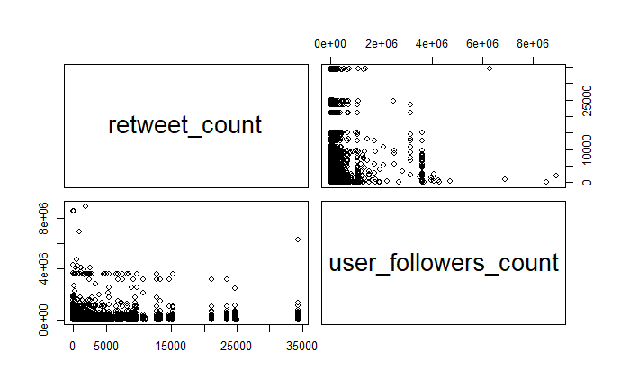

```r
CorrelationRetweetsFollowers <- select(TwitterPoliticalData, c ("retweet_count", "user_followers_count"))
pairs(CorrelationRetweetsFollowers)
```

#Correlation Calculation

```r
calculationcor <- cor(TwitterPoliticalData$retweet_count, TwitterPoliticalData$user_followers_count)
calculationcor
```

```
[1] -0.02470969
```

# There is a weak negative correlation between retweet_count and user_followers_count, as the correlation is less than 0.05

#Corrplot

```r
install.packages("corrplot")
library(corrplot)
```

```r
CorrelationRetweetsFollowersCor <- cor(CorrelationRetweetsFollowers)
CorrelationRetweetsFollowersCor
```

```
                     retweet_count user_followers_count
retweet_count           1.00000000          -0.02470969
user_followers_count   -0.02470969           1.00000000
```

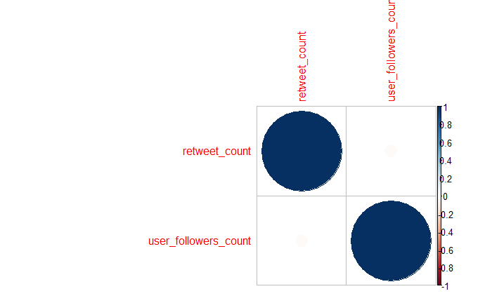

```r
corrplot(CorrelationRetweetsFollowersCor, method = "circle")
```

#Univariate Linear Regression

```r
modelretweets <- lm(user_followers_count ~ user_friends_count, data = TwitterPoliticalData)
modelretweets
```

```
Call:
lm(formula = user_followers_count ~ user_friends_count, data = TwitterPoliticalData)

Coefficients:
       (Intercept)  user_friends_count
           676.287               1.199
```

```r
summary(modelretweets)
```

```
Call:
lm(formula = user_followers_count ~ user_friends_count, data = TwitterPoliticalData)

Residuals:
    Min      1Q  Median      3Q     Max
-169692   -1954   -1078    -728 8921863

Coefficients:
                    Estimate Std. Error t value Pr(>|t|)
(Intercept)        6.763e+02  4.720e+01   14.33   <2e-16 ***
user_friends_count 1.199e+00  5.013e-03  239.19   <2e-16 ***
---
Signif. codes:  0 ‘***’ 0.001 ‘**’ 0.01 ‘*’ 0.05 ‘.’ 0.1 ‘ ’ 1

Residual standard error: 42030 on 900268 degrees of freedom
Multiple R-squared:  0.05975,   Adjusted R-squared:  0.05975
F-statistic: 5.721e+04 on 1 and 900268 DF,  p-value: < 2.2e-16
```

#Visualization with Linear MOdel

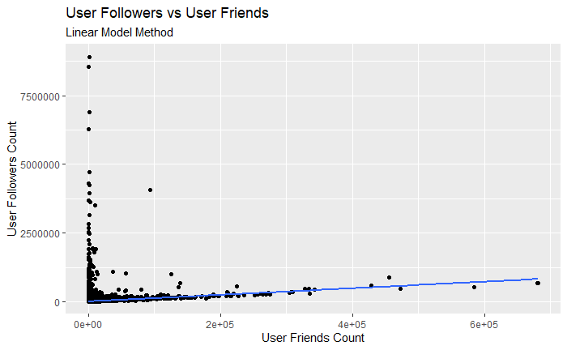

```r
ggplot(data = TwitterPoliticalData, mapping = aes(x = user_friends_count, y = user_followers_count )) +
  geom_point()+
  geom_smooth(method = "lm") +
  labs(title = "User Followers vs User Friends",
       subtitle = "Linear Model Method",
       x = "User Friends Count",
       y = "User Followers Count"
  )
```

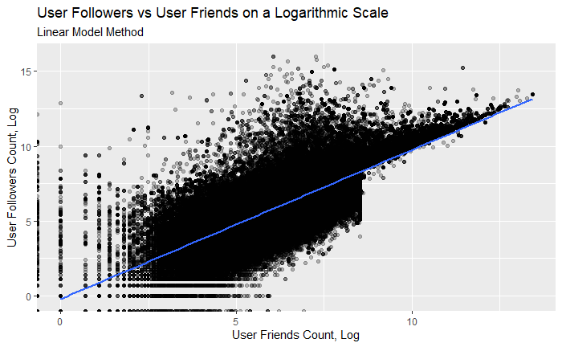

```r
ggplot(data = TwitterPoliticalData, mapping = aes(x = log(user_friends_count), y = log(user_followers_count) )) +
  geom_point(alpha = 0.25)+
  geom_smooth(method = "lm") +
  labs(title = "User Followers vs User Friends on a Logarithmic Scale",
       subtitle = "Linear Model Method",
       x = "User Friends Count, Log",
       y = "User Followers Count, Log"
  )
```

#Prediction with Linear Model >#What would be the user followers when the user friends are 100?

```r
#Correct Data Types
TwitterPoliticalDataCorrected <- read_csv("TwitterPoliticalData.csv",
                                          col_types = cols(
                                            user_friends_count = col_integer(),
                                            user_followers_count = col_integer())
)
```

```r
predictionofvariable <- data.frame(user_friends_count = c(100))
```

```r
predictedPositionofTweets <- predict(modelretweets,predictionofvariable)
cat("At 100 user friends, the followers count is", predictedPositionofTweets )
```

```
At 100 user friends, the followers count is 796.1941
```

#Verification

```r
verification_1 <- TwitterPoliticalDataCorrected %>%
  filter(user_friends_count == 100) %>%
  group_by(user_friends_count) %>%
  summarise(
    Avg_UFC = mean(user_followers_count),
    STDev_UFC = sd(user_followers_count)
  )
cat("The predicted value is outside the models range of prediction indicating the lack of a significant value.")
```

```
The predicted value is outside the models range of prediction indicating the lack of a significant value.
```

#Loess Method

```r
loess_model_data <- TwitterPoliticalData %>%
  select(user_friends_count, user_followers_count) %>%
  slice(1:1000)

loessretweets <- loess( user_followers_count ~user_friends_count, data = loess_model_data)
loessretweets
```

```
Call:
loess(formula = user_followers_count ~ user_friends_count, data = loess_model_data)

Number of Observations: 1000
Equivalent Number of Parameters: 5.34
Residual Standard Error: 20660
```

```r
summary(loessretweets)
```

```
Call:
loess(formula = user_followers_count ~ user_friends_count, data = loess_model_data)

Number of Observations: 1000
Equivalent Number of Parameters: 5.34
Residual Standard Error: 20660
Trace of smoother matrix: 5.85  (exact)

Control settings:
  span     :  0.75
  degree   :  2
  family   :  gaussian
  surface  :  interpolate     cell = 0.2
  normalize:  TRUE
 parametric:  FALSE
drop.square:  FALSE
```

#Prediction with Loess ##What would be the user followers when the user friends are 100?

```r
predictionofvariable <- data.frame(user_friends_count = c(100))
```

```r
predictedPositionofTweets <- predict(loessretweets,predictionofvariable)
cat("At 100 user friends, the followers count is", predictedPositionofTweets )
```

```
At 100 user friends, the followers count is 676.2536
```

```r
verification_2 <- TwitterPoliticalDataCorrected %>%
  filter(user_friends_count == 100) %>%
  group_by(user_friends_count) %>%
  summarise(
    Avg_UFC_loess = mean(user_followers_count),
    STDev_UFC_loess = sd(user_followers_count)
  )
verification_2
```

| user_friends_count | Avg_UFC_loess | STDev_UFC_loess |
| --- | --- | --- |
| 100 | 258.694 | 425.9267 |

```r
cat("The predicted value is within the models range of prediction indicating there is evidence the loess model is a significantone.")
```

```
The predicted value is within the models range of prediction indicating there is evidence the loess model is a significantone.
```

#Visualization with Loess Method

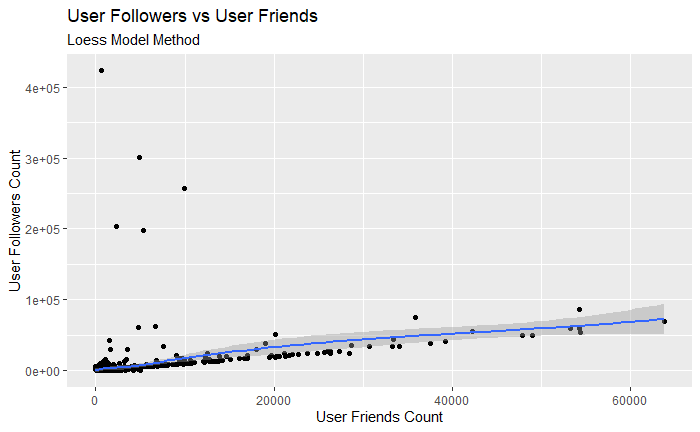

```r
ggplot(data = loess_model_data, mapping = aes(x = user_friends_count, y = user_followers_count )) +
  geom_point()+
  geom_smooth(method = "loess") +
  labs(title = "User Followers vs User Friends",
       subtitle = "Loess Model Method",
       x = "User Friends Count",
       y = "User Followers Count"
      )
```

```r
# install.packages("caret")
library(caret)
```

## Load caTools library

```r
library(caTools)
```

```r
data_model_building <- TwitterPoliticalData %>%
  slice(1:1000)

set.seed(111)
sample <- sample.split(data_model_building$user_friends_count, SplitRatio = 0.75)
train <- subset(data_model_building, sample == TRUE)
test <- subset(data_model_building, sample == FALSE)
```

```r
linear_model <- lm(formula = user_followers_count ~ user_friends_count, data = train)
summary(linear_model)
```

```
Call:
lm(formula = user_followers_count ~ user_friends_count, data = train)

Residuals:
   Min     1Q Median     3Q    Max
 -8517  -2518  -1916  -1634 422105

Coefficients:
                    Estimate Std. Error t value Pr(>|t|)
(Intercept)        1659.9575   926.4673   1.792   0.0736 .
user_friends_count    1.0971     0.1111   9.878   <2e-16 ***
---
Signif. codes:  0 ‘***’ 0.001 ‘**’ 0.01 ‘*’ 0.05 ‘.’ 0.1 ‘ ’ 1

Residual standard error: 22540 on 748 degrees of freedom
Multiple R-squared:  0.1154,    Adjusted R-squared:  0.1142
F-statistic: 97.58 on 1 and 748 DF,  p-value: < 2.2e-16
```

```r
predicted <- predict(linear_model, test)

twitter_error <- data.frame(
  user_friends_count = test$user_friends_count,
  Predictedvalues = predicted
)

twitter_error
```

|  | user_friends_count | Predictedvalues |
| --- | --- | --- |
| 1 | 1087 | 2852.511 |
| 2 | 1814 | 3650.107 |
| 3 | 673 | 2398.310 |
| 4 | 4999 | 7144.388 |
| 5 | 4399 | 6486.125 |
| 6 | 1465 | 3267.217 |
| 7 | 5001 | 7146.582 |
| 8 | 1576 | 3388.996 |
| 9 | 517 | 2227.161 |
| 10 | 1203 | 2979.775 |

[output cut: 240 more lines]

## Mean Absolute Errors

```r
mae <- MAE(twitter_error$user_friends_count, twitter_error$Predictedvalues)
cat("Mean Absolute Error:", mae)
```

```
Mean Absolute Error: 2028.603
```

## MSE

```r
# mse <- MSE(twitter_error$user_friends_count, twitter_error$Predictedvalues)
# cat("Mean Squared Error:", mse)
```

## RSME

```r
rmse <- RMSE(twitter_error$user_friends_count, twitter_error$Predictedvalues)
rmse
```

```
[1] 2151.142
```

## R-Squared

```r
R2 <- R2(twitter_error$user_friends_count, twitter_error$Predictedvalues, form = "traditional")
R2
```

```
[1] 0.9292208
```